# nonlinear_activations_investigation

## Plot Activations & Derivatives

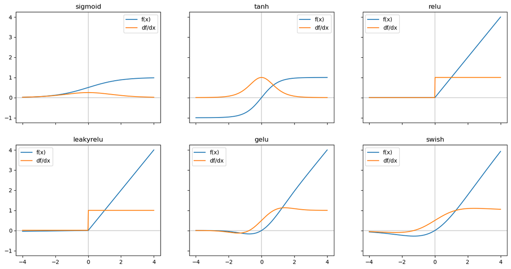

```python
x = np.linspace(-4, 4, 1000)
functions = [sigmoid, tanh, relu, leakyrelu, gelu, swish]
fig, axes = plt.subplots(2, math.ceil(len(functions) / 2), sharex=True, sharey=True, figsize=(16, 8))

for ax, f in zip(axes.ravel(), functions):
    plot_derivative(ax, f, x)

plt.show()
```

### Commentary - Nonlinearities and derivatives

From [Yes you should understand backprop](https://karpathy.medium.com/yes-you-should-understand-backprop-e2f06eab496b) and [CS231n](https://www.youtube.com/watch?v=gYpoJMlgyXA&t=1170s)

#### sigmoid

1. saturated neurons "kill" the gradients
2. sigmoid outputs are not 0-centered
3. `exp` is kind of expensive

#### tanh

1. *is* 0-centered
2. still kills gradients

#### ReLU

1. does *not* saturate (in + region)
2. computationally efficient
3. converges ~6x faster than sigmoid/tanh
4. not 0-centered

> diagnostic: if relu killed neurons during training, learning rate is too high (or weights were poorly initialized)

#### Leaky ReLU

1. All the benefits of ReLU, but leaky negative region doesn't kill neurons

#### GELU

1. Used in BERT, GPT-2, GPT-3
2. Can consider as smooth version of ReLU

#### Swish / SiLU

1. Consider as smooth version of ReLU
2. Very similar to GELU, but has learnable param beta

## What do these derivatives tells us about deep networks?

Can we figure out why vanishing/exploding gradients are a problem? Can we figure out how to resolve?

### Commentary - Implications of Deep Networks

#### tanh

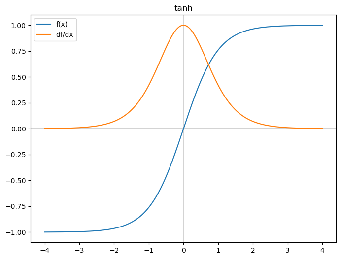

```python
fig, ax = plt.subplots(figsize=(8, 6))
plot_derivative(ax, tanh, x)
plt.show()
```

##### tanh with small weight inits (0.01)

1. Deep layers rapidly tend to 0
2. Means gradients are almost flat (no Δ) - very slow training
3. Means backprop changes all weights to ~0

```
input layer had mean 0.4993269979335089 and std 0.2887438294848731
Hidden layer 1 had mean of 0.0006688113959844324 and std 0.12715667276389442
Hidden layer 2 had mean of -0.0006235104341670708 and std 0.027795514480563874
Hidden layer 3 had mean of -0.0005165674990528159 and std 0.006057649918341069
Hidden layer 4 had mean of 6.339896796073643e-05 and std 0.0013514113295193123
Hidden layer 5 had mean of -1.0204699129120579e-05 and std 0.000302561011009381
Hidden layer 6 had mean of 2.4210472257418546e-06 and std 6.761117430021655e-05
Hidden layer 7 had mean of 4.489122255084105e-08 and std 1.575169583797143e-05
Hidden layer 8 had mean of 3.5602121803510613e-07 and std 3.658292310671153e-06
Hidden layer 9 had mean of -2.3037718370078323e-08 and std 8.000311294138103e-07
Hidden layer 10 had mean of -8.901612152671095e-10 and std 1.7808800835941956e-07
```

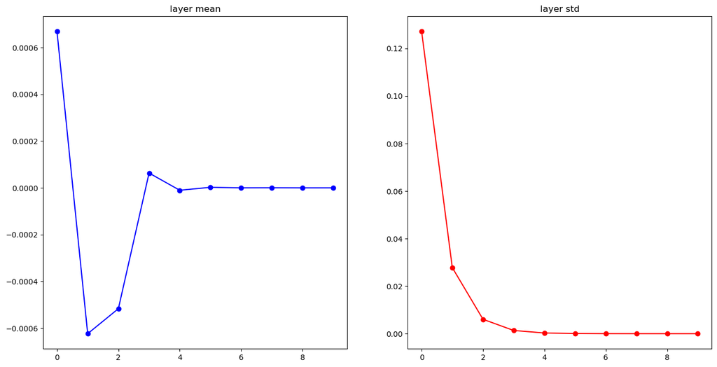

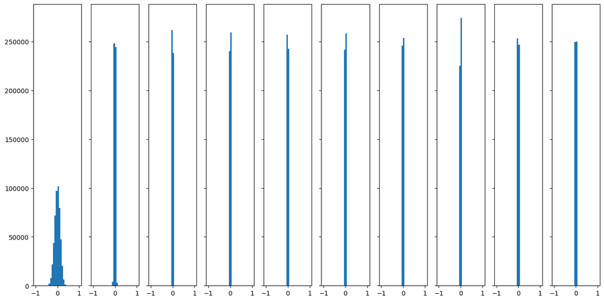

```python
assess_activations(
    batchdims=batchdims,
    ndim=ndim,
    nlayers=nlayers,
    fn=tanh,
    init_scale=0.01,
)
```

##### tanh with large weight inits (1.0)

1. All layers are completely saturated (all -1 or all 1) -- bimodal
2. Means gradients are 0 the entire time

```
input layer had mean 0.4993269979335089 and std 0.2887438294848731
Hidden layer 1 had mean of 0.023923421999398516 and std 0.9678980596298257
Hidden layer 2 had mean of -0.021618186969028636 and std 0.9810165780784369
Hidden layer 3 had mean of -0.04130716165170437 and std 0.9807168211948977
Hidden layer 4 had mean of 0.028619805067378656 and std 0.9810795292276423
Hidden layer 5 had mean of -0.006626934705168004 and std 0.9816677915619244
Hidden layer 6 had mean of 0.01441212670627864 and std 0.9815970640156639
Hidden layer 7 had mean of -0.0016129427397650112 and std 0.9816398102272563
Hidden layer 8 had mean of 0.02931704151804577 and std 0.981304188364376
Hidden layer 9 had mean of 0.0005913641150795206 and std 0.9814839749592613
Hidden layer 10 had mean of -0.0007311281483329459 and std 0.9817494704597497
```

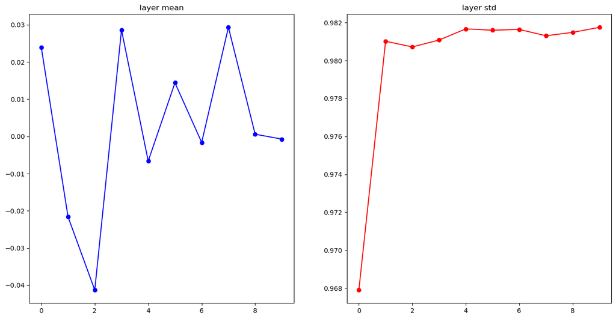

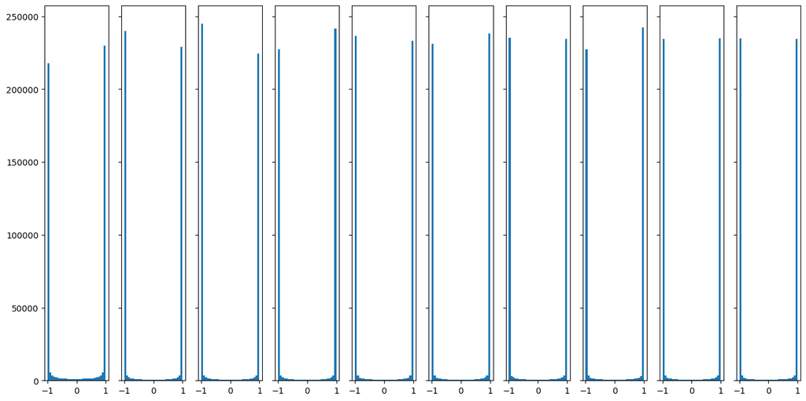

```python
assess_activations(
    batchdims=batchdims,
    ndim=ndim,
    nlayers=nlayers,
    fn=tanh,
    init_scale=1.0,
)
```

##### Xavier initialization

1. scales weights based on neurons in network

```
input layer had mean 0.4993269979335089 and std 0.2887438294848731
Hidden layer 1 had mean of 0.005588986839240443 and std 0.4606289851579146
Hidden layer 2 had mean of -0.009537464731668072 and std 0.3881246508039459
Hidden layer 3 had mean of -0.02699630255875966 and std 0.3374790941703948
Hidden layer 4 had mean of 0.01456831328910708 and std 0.30526573858361994
Hidden layer 5 had mean of -0.008466742631229218 and std 0.2792697074854391
Hidden layer 6 had mean of 0.010161821642350244 and std 0.26119773142473884
Hidden layer 7 had mean of 0.0004367276174591609 and std 0.25557173909994885
Hidden layer 8 had mean of 0.025049462854250155 and std 0.24930851828046807
Hidden layer 9 had mean of -0.004601899974294388 and std 0.23028854857270406
Hidden layer 10 had mean of -0.0017013646043710258 and std 0.2178297761083887
```

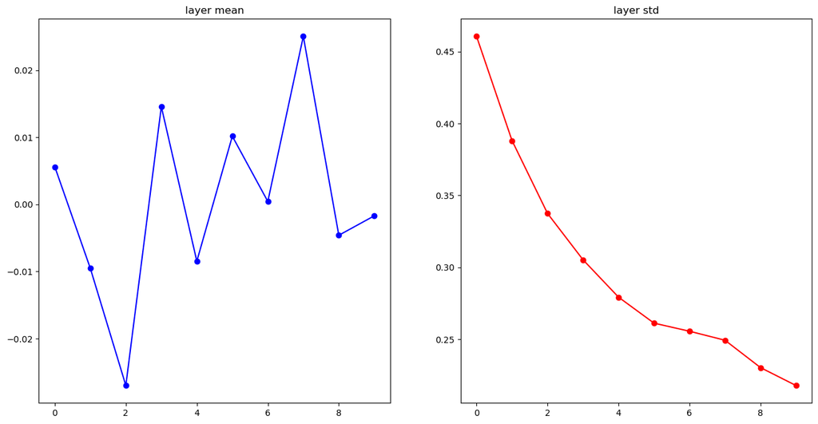

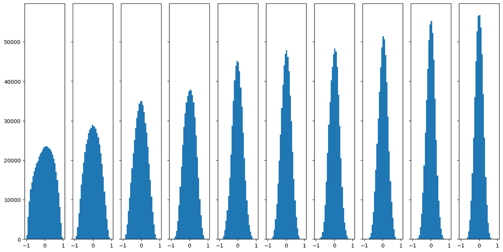

```python
assess_activations(
    batchdims=batchdims,
    ndim=ndim,
    nlayers=nlayers,
    fn=tanh,
    init_scale=1 / np.sqrt(ndim),
)  # Xavier initialization
```

#### ReLU

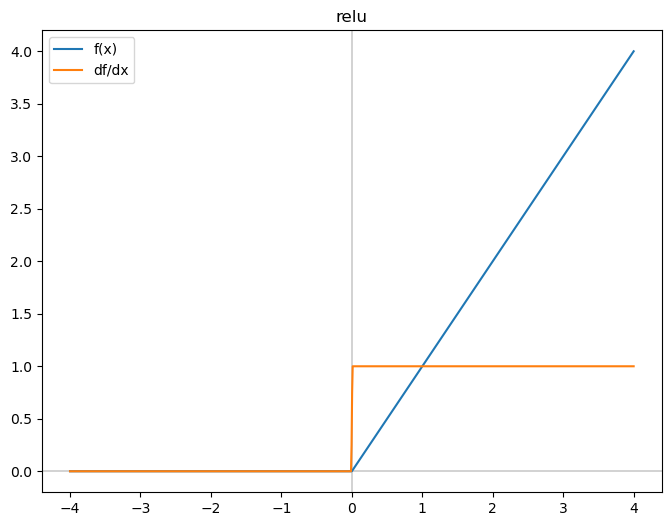

```python
fig, ax = plt.subplots(figsize=(8, 6))
plot_derivative(ax, relu, x)
plt.show()
```

##### Xavier initialization

1. Deep layers rapidly tend to 0 (half the positive neurons each time)

```
input layer had mean 0.4993269979335089 and std 0.2887438294848731
Hidden layer 1 had mean of 0.23169419442907985 and std 0.33014008610344453
Hidden layer 2 had mean of 0.15436956373551483 and std 0.22371149610333627
Hidden layer 3 had mean of 0.10884566227031889 and std 0.15892364367485123
Hidden layer 4 had mean of 0.0775376452144098 and std 0.11251200279532429
Hidden layer 5 had mean of 0.05466119530080249 and std 0.08035670755930245
Hidden layer 6 had mean of 0.03394691948802416 and std 0.05205090401316792
Hidden layer 7 had mean of 0.02312404761592444 and std 0.034479201031139856
Hidden layer 8 had mean of 0.015441496413582551 and std 0.024161399247886933
Hidden layer 9 had mean of 0.011230199302125838 and std 0.01680563372485705
Hidden layer 10 had mean of 0.008267438238630572 and std 0.01234380910142626
```

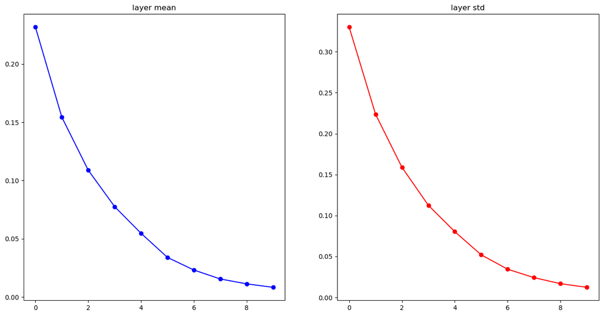

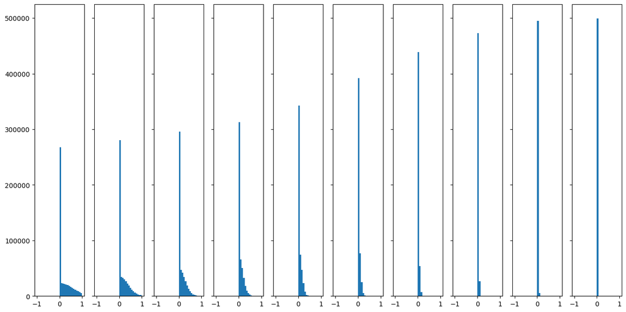

```python
assess_activations(
    batchdims=batchdims,
    ndim=ndim,
    nlayers=nlayers,
    fn=relu,
    init_scale=1 / np.sqrt(ndim),
)  # Xavier initialization
```

##### Xavier initialization (fixed for ReLU)

2. Scale Xavier initialization by 2 to account to ^

```
input layer had mean 0.4993269979335089 and std 0.2887438294848731
Hidden layer 1 had mean of 0.3276650720847133 and std 0.4668885872505126
Hidden layer 2 had mean of 0.30873912747102966 and std 0.4474229922066724
Hidden layer 3 had mean of 0.307862023576333 and std 0.4495039445334474
Hidden layer 4 had mean of 0.31015058085763914 and std 0.4500480111812971
Hidden layer 5 had mean of 0.30921041491967727 and std 0.45456618263205634
Hidden layer 6 had mean of 0.2715753559041932 and std 0.41640723210534314
Hidden layer 7 had mean of 0.26161873404321234 and std 0.39008762974421096
Hidden layer 8 had mean of 0.24706394261732068 and std 0.38658238796619077
Hidden layer 9 had mean of 0.2541104025795074 and std 0.38026808220748004
Hidden layer 10 had mean of 0.26455802363617814 and std 0.39500189124564006
```

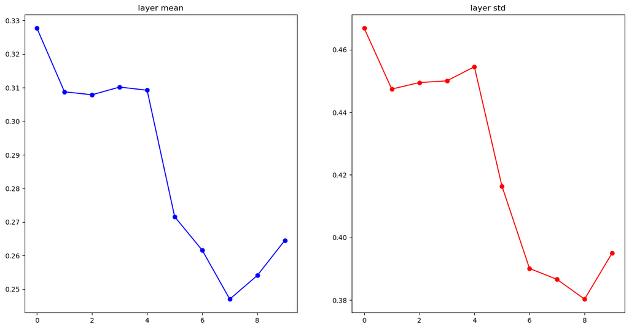

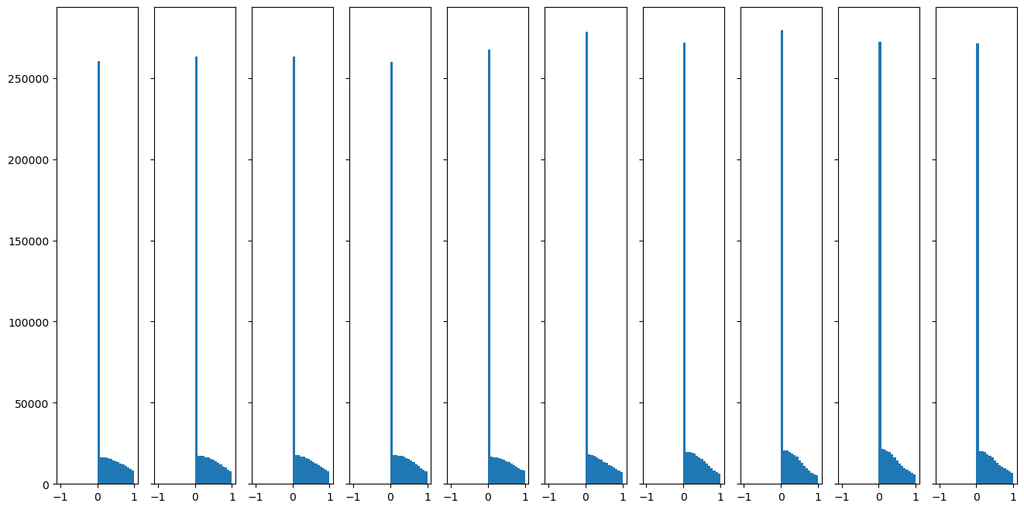

```python
assess_activations(
    batchdims=batchdims,
    ndim=ndim,
    nlayers=nlayers,
    fn=relu,
    init_scale=1 / np.sqrt(ndim / 2),
)  # Xavier initialization fixed for relu
```

> These issues are mostly resolved with batch-norm As seen above, we *want* our weights to be roughly unit gaussian.

> Batch norm adds a layer that takes the weights and normalizes them (for each batch).